# Risk Factor Analysis

## Outcome Variable

**Outcome Variable:** pers_wast

## Predictor Variables

**Intervention Variable:** fhtcm

**Adjustment Set:**

unadjusted

## Stratifying Variables

The analysis was stratified on these variable(s):

- agecat
- studyid
- country

## Data Summary

| agecat | studyid | country | fhtcm | pers_wast | n_cell | n |
| --- | --- | --- | --- | --- | --- | --- |
| 0-24 months | ki1000304b-SAS-CompFeed | INDIA | >=167 cm | 0 | 358 | 824 |
| 0-24 months | ki1000304b-SAS-CompFeed | INDIA | >=167 cm | 1 | 27 | 824 |
| 0-24 months | ki1000304b-SAS-CompFeed | INDIA | <162 cm | 0 | 179 | 824 |
| 0-24 months | ki1000304b-SAS-CompFeed | INDIA | <162 cm | 1 | 15 | 824 |
| 0-24 months | ki1000304b-SAS-CompFeed | INDIA | [162-167) cm | 0 | 222 | 824 |
| 0-24 months | ki1000304b-SAS-CompFeed | INDIA | [162-167) cm | 1 | 23 | 824 |
| 0-24 months | ki1000304b-SAS-FoodSuppl | INDIA | >=167 cm | 0 | 89 | 370 |
| 0-24 months | ki1000304b-SAS-FoodSuppl | INDIA | >=167 cm | 1 | 11 | 370 |
| 0-24 months | ki1000304b-SAS-FoodSuppl | INDIA | <162 cm | 0 | 118 | 370 |
| 0-24 months | ki1000304b-SAS-FoodSuppl | INDIA | <162 cm | 1 | 34 | 370 |
| 0-24 months | ki1000304b-SAS-FoodSuppl | INDIA | [162-167) cm | 0 | 100 | 370 |
| 0-24 months | ki1000304b-SAS-FoodSuppl | INDIA | [162-167) cm | 1 | 18 | 370 |
| 0-24 months | ki1101329-Keneba | GAMBIA | >=167 cm | 0 | 1038 | 1720 |
| 0-24 months | ki1101329-Keneba | GAMBIA | >=167 cm | 1 | 69 | 1720 |
| 0-24 months | ki1101329-Keneba | GAMBIA | <162 cm | 0 | 112 | 1720 |
| 0-24 months | ki1101329-Keneba | GAMBIA | <162 cm | 1 | 12 | 1720 |
| 0-24 months | ki1101329-Keneba | GAMBIA | [162-167) cm | 0 | 466 | 1720 |
| 0-24 months | ki1101329-Keneba | GAMBIA | [162-167) cm | 1 | 23 | 1720 |
| 0-24 months | ki1119695-PROBIT | BELARUS | >=167 cm | 0 | 11639 | 12524 |
| 0-24 months | ki1119695-PROBIT | BELARUS | >=167 cm | 1 | 93 | 12524 |
| 0-24 months | ki1119695-PROBIT | BELARUS | <162 cm | 0 | 166 | 12524 |
| 0-24 months | ki1119695-PROBIT | BELARUS | <162 cm | 1 | 2 | 12524 |
| 0-24 months | ki1119695-PROBIT | BELARUS | [162-167) cm | 0 | 621 | 12524 |
| 0-24 months | ki1119695-PROBIT | BELARUS | [162-167) cm | 1 | 3 | 12524 |
| 0-24 months | ki1135781-COHORTS | GUATEMALA | >=167 cm | 0 | 55 | 424 |
| 0-24 months | ki1135781-COHORTS | GUATEMALA | >=167 cm | 1 | 1 | 424 |
| 0-24 months | ki1135781-COHORTS | GUATEMALA | <162 cm | 0 | 237 | 424 |
| 0-24 months | ki1135781-COHORTS | GUATEMALA | <162 cm | 1 | 12 | 424 |
| 0-24 months | ki1135781-COHORTS | GUATEMALA | [162-167) cm | 0 | 116 | 424 |
| 0-24 months | ki1135781-COHORTS | GUATEMALA | [162-167) cm | 1 | 3 | 424 |
| 0-6 months | ki1101329-Keneba | GAMBIA | >=167 cm | 0 | 927 | 1489 |
| 0-6 months | ki1101329-Keneba | GAMBIA | >=167 cm | 1 | 32 | 1489 |
| 0-6 months | ki1101329-Keneba | GAMBIA | <162 cm | 0 | 103 | 1489 |
| 0-6 months | ki1101329-Keneba | GAMBIA | <162 cm | 1 | 7 | 1489 |
| 0-6 months | ki1101329-Keneba | GAMBIA | [162-167) cm | 0 | 411 | 1489 |
| 0-6 months | ki1101329-Keneba | GAMBIA | [162-167) cm | 1 | 9 | 1489 |
| 0-6 months | ki1119695-PROBIT | BELARUS | >=167 cm | 0 | 10294 | 12014 |
| 0-6 months | ki1119695-PROBIT | BELARUS | >=167 cm | 1 | 962 | 12014 |
| 0-6 months | ki1119695-PROBIT | BELARUS | <162 cm | 0 | 145 | 12014 |
| 0-6 months | ki1119695-PROBIT | BELARUS | <162 cm | 1 | 16 | 12014 |
| 0-6 months | ki1119695-PROBIT | BELARUS | [162-167) cm | 0 | 547 | 12014 |
| 0-6 months | ki1119695-PROBIT | BELARUS | [162-167) cm | 1 | 50 | 12014 |
| 6-24 months | ki1000304b-SAS-CompFeed | INDIA | >=167 cm | 0 | 358 | 824 |
| 6-24 months | ki1000304b-SAS-CompFeed | INDIA | >=167 cm | 1 | 27 | 824 |
| 6-24 months | ki1000304b-SAS-CompFeed | INDIA | <162 cm | 0 | 179 | 824 |
| 6-24 months | ki1000304b-SAS-CompFeed | INDIA | <162 cm | 1 | 15 | 824 |
| 6-24 months | ki1000304b-SAS-CompFeed | INDIA | [162-167) cm | 0 | 222 | 824 |
| 6-24 months | ki1000304b-SAS-CompFeed | INDIA | [162-167) cm | 1 | 23 | 824 |
| 6-24 months | ki1000304b-SAS-FoodSuppl | INDIA | >=167 cm | 0 | 89 | 370 |
| 6-24 months | ki1000304b-SAS-FoodSuppl | INDIA | >=167 cm | 1 | 11 | 370 |
| 6-24 months | ki1000304b-SAS-FoodSuppl | INDIA | <162 cm | 0 | 118 | 370 |
| 6-24 months | ki1000304b-SAS-FoodSuppl | INDIA | <162 cm | 1 | 34 | 370 |
| 6-24 months | ki1000304b-SAS-FoodSuppl | INDIA | [162-167) cm | 0 | 100 | 370 |
| 6-24 months | ki1000304b-SAS-FoodSuppl | INDIA | [162-167) cm | 1 | 18 | 370 |
| 6-24 months | ki1101329-Keneba | GAMBIA | >=167 cm | 0 | 1038 | 1720 |
| 6-24 months | ki1101329-Keneba | GAMBIA | >=167 cm | 1 | 69 | 1720 |
| 6-24 months | ki1101329-Keneba | GAMBIA | <162 cm | 0 | 112 | 1720 |
| 6-24 months | ki1101329-Keneba | GAMBIA | <162 cm | 1 | 12 | 1720 |
| 6-24 months | ki1101329-Keneba | GAMBIA | [162-167) cm | 0 | 466 | 1720 |
| 6-24 months | ki1101329-Keneba | GAMBIA | [162-167) cm | 1 | 23 | 1720 |
| 6-24 months | ki1119695-PROBIT | BELARUS | >=167 cm | 0 | 11639 | 12524 |
| 6-24 months | ki1119695-PROBIT | BELARUS | >=167 cm | 1 | 93 | 12524 |
| 6-24 months | ki1119695-PROBIT | BELARUS | <162 cm | 0 | 166 | 12524 |
| 6-24 months | ki1119695-PROBIT | BELARUS | <162 cm | 1 | 2 | 12524 |
| 6-24 months | ki1119695-PROBIT | BELARUS | [162-167) cm | 0 | 621 | 12524 |
| 6-24 months | ki1119695-PROBIT | BELARUS | [162-167) cm | 1 | 3 | 12524 |
| 6-24 months | ki1135781-COHORTS | GUATEMALA | >=167 cm | 0 | 55 | 424 |
| 6-24 months | ki1135781-COHORTS | GUATEMALA | >=167 cm | 1 | 1 | 424 |
| 6-24 months | ki1135781-COHORTS | GUATEMALA | <162 cm | 0 | 237 | 424 |
| 6-24 months | ki1135781-COHORTS | GUATEMALA | <162 cm | 1 | 12 | 424 |
| 6-24 months | ki1135781-COHORTS | GUATEMALA | [162-167) cm | 0 | 116 | 424 |
| 6-24 months | ki1135781-COHORTS | GUATEMALA | [162-167) cm | 1 | 3 | 424 |

The following strata were considered:

- agecat: 0-24 months, studyid: ki1000304b-SAS-CompFeed, country: INDIA
- agecat: 0-24 months, studyid: ki1000304b-SAS-FoodSuppl, country: INDIA
- agecat: 0-24 months, studyid: ki1101329-Keneba, country: GAMBIA
- agecat: 0-24 months, studyid: ki1119695-PROBIT, country: BELARUS
- agecat: 0-24 months, studyid: ki1135781-COHORTS, country: GUATEMALA
- agecat: 0-6 months, studyid: ki1101329-Keneba, country: GAMBIA
- agecat: 0-6 months, studyid: ki1119695-PROBIT, country: BELARUS
- agecat: 6-24 months, studyid: ki1000304b-SAS-CompFeed, country: INDIA
- agecat: 6-24 months, studyid: ki1000304b-SAS-FoodSuppl, country: INDIA
- agecat: 6-24 months, studyid: ki1101329-Keneba, country: GAMBIA
- agecat: 6-24 months, studyid: ki1119695-PROBIT, country: BELARUS
- agecat: 6-24 months, studyid: ki1135781-COHORTS, country: GUATEMALA

### Dropped Strata

Some strata were dropped due to rare outcomes:

- agecat: 0-24 months, studyid: ki1119695-PROBIT, country: BELARUS
- agecat: 0-24 months, studyid: ki1135781-COHORTS, country: GUATEMALA
- agecat: 6-24 months, studyid: ki1119695-PROBIT, country: BELARUS
- agecat: 6-24 months, studyid: ki1135781-COHORTS, country: GUATEMALA

## Methods Detail

We’re interested in the causal parameters $E[Y_a]$ for all values of $a \in \mathcal{A}$. These parameters represent the mean outcome if, possibly contrary to fact, we intervened to set all units to have $A=a$. Under the randomization and positivity assumptions, these are identified by the statistical parameters $\psi_a=E_W[E_{Y|A,W}(Y|A=a,W)]$. In addition, we’re interested in the mean of $Y$, $E[Y]$ under no intervention (the observed mean). We will estimate these parameters by using SuperLearner to fit the relevant likelihood factors – $E_{Y|A,W}(Y|A=a,W)$ and $p(A=a|W)$, and then updating our likelihood fit using a joint TMLE.

For unadjusted analyses ($W=\{\}$), initial likelihoods were estimated using Lrnr_glm to estimate the simple $E(Y|A)$ and Lrnr_mean to estimate $p(A)$. For adjusted analyses, a small library containing Lrnr_glmnet, Lrnr_xgboost, and Lrnr_mean was used.

Having estimated these parameters, we will then use the delta method to estimate relative risks and attributable risks relative to a prespecified baseline level of $A$.

# Results Detail

## Results Plots

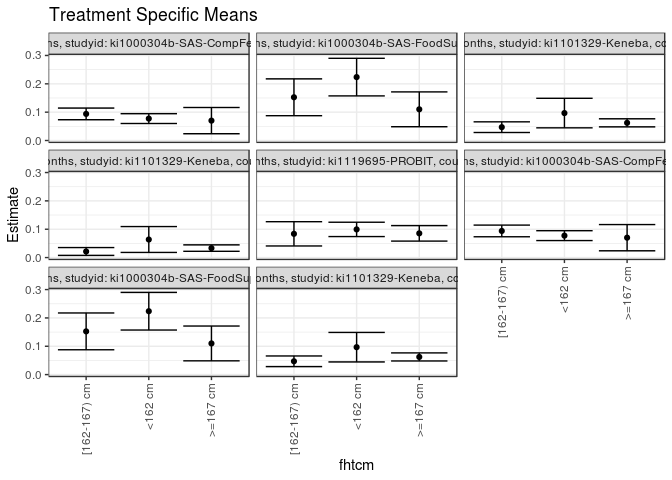

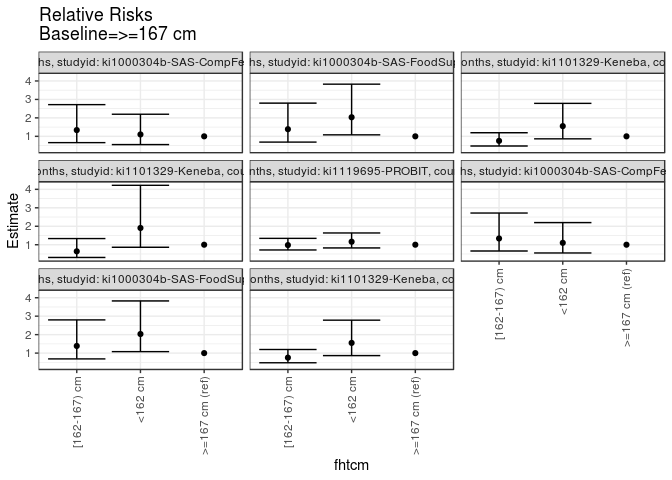

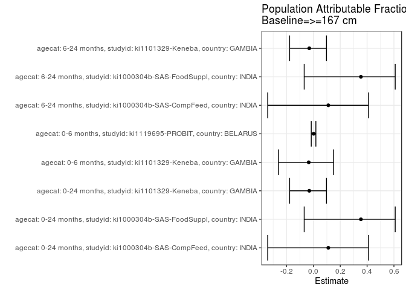

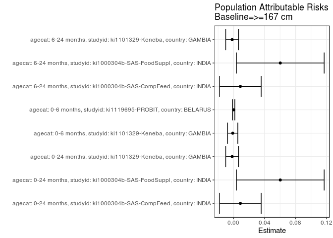

## Results Table

### Parameter: TSM

| agecat | studyid | country | intervention_level | baseline_level | estimate | ci_lower | ci_upper |
| --- | --- | --- | --- | --- | --- | --- | --- |
| 0-24 months | ki1000304b-SAS-CompFeed | INDIA | >=167 cm | NA | 0.0701299 | 0.0238669 | 0.1163929 |
| 0-24 months | ki1000304b-SAS-CompFeed | INDIA | <162 cm | NA | 0.0773196 | 0.0599210 | 0.0947181 |
| 0-24 months | ki1000304b-SAS-CompFeed | INDIA | [162-167) cm | NA | 0.0938776 | 0.0732925 | 0.1144626 |
| 0-24 months | ki1000304b-SAS-FoodSuppl | INDIA | >=167 cm | NA | 0.1100000 | 0.0485917 | 0.1714083 |
| 0-24 months | ki1000304b-SAS-FoodSuppl | INDIA | <162 cm | NA | 0.2236842 | 0.1573480 | 0.2900205 |
| 0-24 months | ki1000304b-SAS-FoodSuppl | INDIA | [162-167) cm | NA | 0.1525424 | 0.0875819 | 0.2175028 |
| 0-24 months | ki1101329-Keneba | GAMBIA | >=167 cm | NA | 0.0623306 | 0.0480852 | 0.0765761 |
| 0-24 months | ki1101329-Keneba | GAMBIA | <162 cm | NA | 0.0967742 | 0.0447217 | 0.1488267 |
| 0-24 months | ki1101329-Keneba | GAMBIA | [162-167) cm | NA | 0.0470348 | 0.0282646 | 0.0658049 |
| 0-6 months | ki1101329-Keneba | GAMBIA | >=167 cm | NA | 0.0333681 | 0.0219976 | 0.0447386 |
| 0-6 months | ki1101329-Keneba | GAMBIA | <162 cm | NA | 0.0636364 | 0.0180040 | 0.1092687 |
| 0-6 months | ki1101329-Keneba | GAMBIA | [162-167) cm | NA | 0.0214286 | 0.0075750 | 0.0352822 |
| 0-6 months | ki1119695-PROBIT | BELARUS | >=167 cm | NA | 0.0854655 | 0.0581436 | 0.1127875 |
| 0-6 months | ki1119695-PROBIT | BELARUS | <162 cm | NA | 0.0993789 | 0.0741112 | 0.1246466 |
| 0-6 months | ki1119695-PROBIT | BELARUS | [162-167) cm | NA | 0.0837521 | 0.0409389 | 0.1265653 |
| 6-24 months | ki1000304b-SAS-CompFeed | INDIA | >=167 cm | NA | 0.0701299 | 0.0238669 | 0.1163929 |
| 6-24 months | ki1000304b-SAS-CompFeed | INDIA | <162 cm | NA | 0.0773196 | 0.0599210 | 0.0947181 |
| 6-24 months | ki1000304b-SAS-CompFeed | INDIA | [162-167) cm | NA | 0.0938776 | 0.0732925 | 0.1144626 |
| 6-24 months | ki1000304b-SAS-FoodSuppl | INDIA | >=167 cm | NA | 0.1100000 | 0.0485917 | 0.1714083 |
| 6-24 months | ki1000304b-SAS-FoodSuppl | INDIA | <162 cm | NA | 0.2236842 | 0.1573480 | 0.2900205 |
| 6-24 months | ki1000304b-SAS-FoodSuppl | INDIA | [162-167) cm | NA | 0.1525424 | 0.0875819 | 0.2175028 |
| 6-24 months | ki1101329-Keneba | GAMBIA | >=167 cm | NA | 0.0623306 | 0.0480852 | 0.0765761 |
| 6-24 months | ki1101329-Keneba | GAMBIA | <162 cm | NA | 0.0967742 | 0.0447217 | 0.1488267 |
| 6-24 months | ki1101329-Keneba | GAMBIA | [162-167) cm | NA | 0.0470348 | 0.0282646 | 0.0658049 |

### Parameter: E(Y)

| agecat | studyid | country | intervention_level | baseline_level | estimate | ci_lower | ci_upper |
| --- | --- | --- | --- | --- | --- | --- | --- |
| 0-24 months | ki1000304b-SAS-CompFeed | INDIA | NA | NA | 0.0788835 | 0.0568416 | 0.1009254 |
| 0-24 months | ki1000304b-SAS-FoodSuppl | INDIA | NA | NA | 0.1702703 | 0.1319196 | 0.2086209 |
| 0-24 months | ki1101329-Keneba | GAMBIA | NA | NA | 0.0604651 | 0.0491978 | 0.0717324 |
| 0-6 months | ki1101329-Keneba | GAMBIA | NA | NA | 0.0322364 | 0.0232620 | 0.0412108 |
| 0-6 months | ki1119695-PROBIT | BELARUS | NA | NA | 0.0855668 | 0.0580084 | 0.1131253 |
| 6-24 months | ki1000304b-SAS-CompFeed | INDIA | NA | NA | 0.0788835 | 0.0568416 | 0.1009254 |
| 6-24 months | ki1000304b-SAS-FoodSuppl | INDIA | NA | NA | 0.1702703 | 0.1319196 | 0.2086209 |
| 6-24 months | ki1101329-Keneba | GAMBIA | NA | NA | 0.0604651 | 0.0491978 | 0.0717324 |

### Parameter: RR

| agecat | studyid | country | intervention_level | baseline_level | estimate | ci_lower | ci_upper |
| --- | --- | --- | --- | --- | --- | --- | --- |
| 0-24 months | ki1000304b-SAS-CompFeed | INDIA | >=167 cm | >=167 cm | 1.0000000 | 1.0000000 | 1.000000 |
| 0-24 months | ki1000304b-SAS-CompFeed | INDIA | <162 cm | >=167 cm | 1.1025200 | 0.5529835 | 2.198168 |
| 0-24 months | ki1000304b-SAS-CompFeed | INDIA | [162-167) cm | >=167 cm | 1.3386243 | 0.6595285 | 2.716964 |
| 0-24 months | ki1000304b-SAS-FoodSuppl | INDIA | >=167 cm | >=167 cm | 1.0000000 | 1.0000000 | 1.000000 |
| 0-24 months | ki1000304b-SAS-FoodSuppl | INDIA | <162 cm | >=167 cm | 2.0334928 | 1.0807070 | 3.826285 |
| 0-24 months | ki1000304b-SAS-FoodSuppl | INDIA | [162-167) cm | >=167 cm | 1.3867488 | 0.6871668 | 2.798553 |
| 0-24 months | ki1101329-Keneba | GAMBIA | >=167 cm | >=167 cm | 1.0000000 | 1.0000000 | 1.000000 |
| 0-24 months | ki1101329-Keneba | GAMBIA | <162 cm | >=167 cm | 1.5525947 | 0.8654636 | 2.785271 |
| 0-24 months | ki1101329-Keneba | GAMBIA | [162-167) cm | >=167 cm | 0.7546012 | 0.4764242 | 1.195202 |
| 0-6 months | ki1101329-Keneba | GAMBIA | >=167 cm | >=167 cm | 1.0000000 | 1.0000000 | 1.000000 |
| 0-6 months | ki1101329-Keneba | GAMBIA | <162 cm | >=167 cm | 1.9071023 | 0.8621358 | 4.218638 |
| 0-6 months | ki1101329-Keneba | GAMBIA | [162-167) cm | >=167 cm | 0.6421875 | 0.3092258 | 1.333669 |
| 0-6 months | ki1119695-PROBIT | BELARUS | >=167 cm | >=167 cm | 1.0000000 | 1.0000000 | 1.000000 |
| 0-6 months | ki1119695-PROBIT | BELARUS | <162 cm | >=167 cm | 1.1627949 | 0.8256904 | 1.637529 |
| 0-6 months | ki1119695-PROBIT | BELARUS | [162-167) cm | >=167 cm | 0.9799517 | 0.7147380 | 1.343577 |
| 6-24 months | ki1000304b-SAS-CompFeed | INDIA | >=167 cm | >=167 cm | 1.0000000 | 1.0000000 | 1.000000 |
| 6-24 months | ki1000304b-SAS-CompFeed | INDIA | <162 cm | >=167 cm | 1.1025200 | 0.5529835 | 2.198168 |
| 6-24 months | ki1000304b-SAS-CompFeed | INDIA | [162-167) cm | >=167 cm | 1.3386243 | 0.6595285 | 2.716964 |
| 6-24 months | ki1000304b-SAS-FoodSuppl | INDIA | >=167 cm | >=167 cm | 1.0000000 | 1.0000000 | 1.000000 |
| 6-24 months | ki1000304b-SAS-FoodSuppl | INDIA | <162 cm | >=167 cm | 2.0334928 | 1.0807070 | 3.826285 |
| 6-24 months | ki1000304b-SAS-FoodSuppl | INDIA | [162-167) cm | >=167 cm | 1.3867488 | 0.6871668 | 2.798553 |
| 6-24 months | ki1101329-Keneba | GAMBIA | >=167 cm | >=167 cm | 1.0000000 | 1.0000000 | 1.000000 |
| 6-24 months | ki1101329-Keneba | GAMBIA | <162 cm | >=167 cm | 1.5525947 | 0.8654636 | 2.785271 |
| 6-24 months | ki1101329-Keneba | GAMBIA | [162-167) cm | >=167 cm | 0.7546012 | 0.4764242 | 1.195202 |

### Parameter: PAR

| agecat | studyid | country | intervention_level | baseline_level | estimate | ci_lower | ci_upper |
| --- | --- | --- | --- | --- | --- | --- | --- |
| 0-24 months | ki1000304b-SAS-CompFeed | INDIA | >=167 cm | NA | 0.0087536 | -0.0180969 | 0.0356041 |
| 0-24 months | ki1000304b-SAS-FoodSuppl | INDIA | >=167 cm | NA | 0.0602703 | 0.0036718 | 0.1168687 |
| 0-24 months | ki1101329-Keneba | GAMBIA | >=167 cm | NA | -0.0018655 | -0.0101521 | 0.0064211 |
| 0-6 months | ki1101329-Keneba | GAMBIA | >=167 cm | NA | -0.0011317 | -0.0077112 | 0.0054478 |
| 0-6 months | ki1119695-PROBIT | BELARUS | >=167 cm | NA | 0.0001013 | -0.0013772 | 0.0015798 |
| 6-24 months | ki1000304b-SAS-CompFeed | INDIA | >=167 cm | NA | 0.0087536 | -0.0180969 | 0.0356041 |
| 6-24 months | ki1000304b-SAS-FoodSuppl | INDIA | >=167 cm | NA | 0.0602703 | 0.0036718 | 0.1168687 |
| 6-24 months | ki1101329-Keneba | GAMBIA | >=167 cm | NA | -0.0018655 | -0.0101521 | 0.0064211 |

### Parameter: PAF

| agecat | studyid | country | intervention_level | baseline_level | estimate | ci_lower | ci_upper |
| --- | --- | --- | --- | --- | --- | --- | --- |
| 0-24 months | ki1000304b-SAS-CompFeed | INDIA | >=167 cm | NA | 0.1109690 | -0.3408593 | 0.4105451 |
| 0-24 months | ki1000304b-SAS-FoodSuppl | INDIA | >=167 cm | NA | 0.3539683 | -0.0689019 | 0.6095460 |
| 0-24 months | ki1101329-Keneba | GAMBIA | >=167 cm | NA | -0.0308526 | -0.1773078 | 0.0973838 |
| 0-6 months | ki1101329-Keneba | GAMBIA | >=167 cm | NA | -0.0351060 | -0.2604545 | 0.1499539 |
| 0-6 months | ki1119695-PROBIT | BELARUS | >=167 cm | NA | 0.0011840 | -0.0161773 | 0.0182487 |
| 6-24 months | ki1000304b-SAS-CompFeed | INDIA | >=167 cm | NA | 0.1109690 | -0.3408593 | 0.4105451 |
| 6-24 months | ki1000304b-SAS-FoodSuppl | INDIA | >=167 cm | NA | 0.3539683 | -0.0689019 | 0.6095460 |
| 6-24 months | ki1101329-Keneba | GAMBIA | >=167 cm | NA | -0.0308526 | -0.1773078 | 0.0973838 |